# On campus, more crimes than reported

[interactive chart not shown]

One incident in NYU’s daily crime log, Jan.–June 2023

Hover over a dot for details

Map data © OpenStreetMap contributors

# On campus, more crimes than reported

Scroll

In the 2023 NYU Annual Campus Security and Fire Safety Report, the NYU Department of Campus Safety reported **193** crime incidents that took place over 2022.

However, larceny and sexual harassment, the two most frequent crimes on campus and in the city, were not included in the Report.

They were instead kept in a daily crime log – scattered and not ready for public review – where all crime incidents summed up to a much larger number of **852**.

In a recent examination, the Washington Square News reviewed a series of campus security statistics and documents. The investigation discovered that the Clery Act, a federal law created to raise campus crime awareness, has long indulged universities like NYU to keep the actual crime statistics from their community members.

2022 was not the only year in which there was a large discrepancy between the Report and the crime log. The discrepancies date back to 2016, as far back as the crime log can trace. In 2021, the Annual Report documented 180 incidents, but the crime log recorded 657. In 2020, it was 97 and 422.

In the first half of 2023, NYU Campus Safety recorded 485 incidents within NYU’s Washington Square campus, whereas NYPD documented 322 incidents. According to the investigation, the two departments shared 30 incidents.

“I don’t think that necessarily campuses are often hiding crime,” said Dennis Gregory, a leading researcher on the Clery Act and an associate professor of Higher Education and Community College Leadership at Old Dominion University in Norfolk, Virginia.

“But I still think they’re reluctant to reach out and do the kinds of things that might be great crime prevention, because they don’t want to make the campuses feel so unsafe that people don’t want to come to school there.”

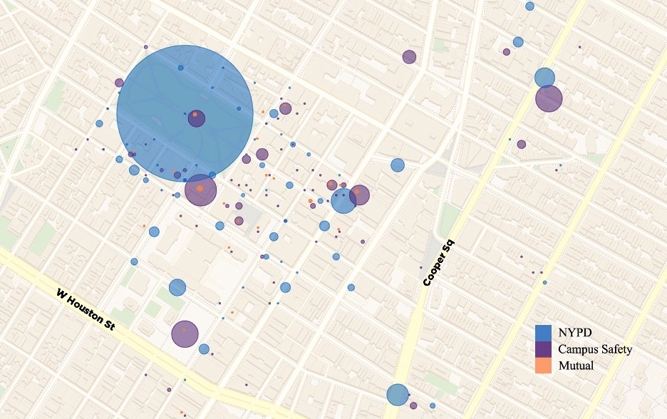

The map illustrates on-campus crime from the first half of 2023. The size of the circle represents the number of crime incidents reported by different agencies.

## The elephant on campus

The Annual Security and Campus Safety Report, published every year at the end of September, is a product of the Clery Act. Established in 1990, the Jeanne Clery Disclosure of Campus Security Policy and Campus Crime Statistics Act was renamed in 1998 in memory of Jeanne Clery, a student who was raped and murdered in her dorm room at Lehigh University in Bethlehem, PA.

Community members can find the NYU Daily Crime Log in the [link](https://www.nyu.edu/life/safety-health-wellness/campus-safety/crime-log.html) provided in the Report, or by simply Googling “NYU crime log” and clicking on the first tab. When noticing a crime pattern on campus, Campus Safety will send out a mass email whose title starts with “NYU Clery Campus Notice.”

The most recent Report recorded 193 incidents that took place in 2022. With 79 alcohol law violations topping the list, the university also reported seven robberies, 19 burglaries and three rapes.

Amended seven times since its creation, the Act now requires universities to cover a list of violent crimes that are likely to result in serious physical, mental or financial harm. However, many universities, including NYU, Columbia University and CUNYs, omit the non-mandatory crimes in their Annual Reports.

Gregory said the Clery Act should compel the universities to expand their crime coverage.

“If you look at the crime statistics that are put out by the FBI, despite the high-profile crimes, we see that violent crime is going down in the country, while property crimes are going up,” Gregory said.

In addition to limited crime coverage, NYU Campus Security reports on a confined area. In the Clery Act Appendix published by the U.S. Department of Education, universities are required to report on crimes that take place in the “reasonably contiguous geographic area.”

However, as a university that blends with the city, there is no clear delineation that separates NYU from its surrounding area. During the past three years, NYU Campus Safety has grappled with the boundaries that define the geography, adjusting the map each time the Report was published.

“In New York,” Gregory said, “where there is a very urban campus and you’re walking city streets in between campus buildings, it becomes even more difficult in a large urban area where the campus is right in the middle of that urban area.”

In compliance with the Act, NYU Campus Safety reports crimes in buildings owned or used by the university or student organizations. Crimes that occur on adjacent sidewalks will be included as well.

With the map boundaries closely tailored to the buildings, Campus Security is not obliged to record crimes as close as one block away. For example, if a student is robbed in the W 4 St-Washington Square Station or loses their property in Negril Village across the street from the Kimmel Center for University Life, Campus Safety is not required to, and does not, record the incident.

“Regardless of what we determine our Clery geography to be, NYU does not have security-related jurisdiction outside of its owned and controlled spaces,” Matthew Shelosky, associate director of the Department of Campus Safety Communications and Engagement, said.

While Campus Safety overlooks campus crimes outside the campus geography, it doesn’t always record those within the boundaries.

Unlike sworn-in officers at law enforcement agencies, Campus Safety officers do not have the right to carry weapons or make arrests. After the safety officers arrive at the scene and put things under control, they’ll have to refer the violent crimes to the NYPD.

But the counterpart doesn’t always do the same. In the first half of 2023, among the 167 felonies within campus geography, the NYPD only referred 16 incidents to Campus Safety.

“City municipal police departments are not required legally to report crimes to the campus police officials for the inclusion in the Clery Report … The methods used by local municipal departments to gather crime data in their cities are quite different from what we do with regards to the Clery data,” Gregory said. “So establishing relationships between campus police officials and local municipal police officials is absolutely critical.”

The lack of communication between the two departments has caused Campus Safety to underreport about a third of incidents in or near university buildings.

At Founders Hall, one of NYU’s newest residence halls that hosts over 700 first-year students, Campus Safety in the past two years recorded 40 crimes but overlooked 22. John A. Paulson Center, the multi-purpose facility that opened this January, missed a third of the 32 crimes on its premises. Even Elmer Holmes Bobst, the main library at the heart of NYU’s Washington Square campus, was found to underreport an average of 18 out of 56 crimes chronically.

The NYPD didn’t reply to repeated requests for comment.

## A Spinning Wheel

In their research published in 2003 in the Journal of College Student Development, Dr. Steven Janosik from Virginia Tech and Dr. Donald Gehring from Bowling Green State University surveyed 9,150 undergraduate students from 305 different universities on their knowledge about the Clery Act. The research found that only a quarter of students were aware of the Clery Act and the Annual Report. Fewer – about 10 percent – students used the crime statistics as part of choosing their college.

“It is clear that students remain unaware of the Act and do not use the information contained in the summary or annual report,” Gregory commented in a literature review published in Stetson Law Review.

As an unfunded federal mandate, the Clery Act asks a lot from the universities but does not sponsor them to do so.

“There are no incentives for people to do it well,” Gregory said.

Since 1990, the federal Department of Education has fined universities $15,000 to $25,000 for failing the annual Clery Act audit. For higher-profile cases that involved greater fault, the fine can be as high as millions of dollars. Pennsylvania State University and Michigan State University were fined $2.4 million and $4.5 million in the wake of notorious sexual abuses.

Over time, researchers have gradually gained interest in the Clery Act, conducting more case studies across the nation. During the past two decades, the research on the Clery Act has doubled to an average of three publications a year; meanwhile, the number of critics has dropped.

“The Clery Act and crime on campus is, in my mind, an indictment of the way we look at crime generally across the country. And the need for Clery has become increasingly important as a result of that,” Gregory said.

However, more than three decades after the law was first implemented, the Clery Act still provides no positive incentives for universities to thoroughly investigate all crimes on campus and its premises.

Although researchers like Gregory have proposed many solutions – conducting campus-wide surveys, acquiring data from police departments, expanding the reporting area by five miles, etc. – most universities, including NYU, have never gone beyond the basic requirements.